# Blogdown Tutorial

In this tutorial, I’m going to walk you through how to use GitHub to host a static Hugo blog using RStudio the R package `{blogdown}`.

### This tutorial assumes that you have set-up a GitHub account and a personal webpage (e.g., USERNAME.github.io). It also assumes that you have downloaded GitHub desktop and have linked your site’s repository there. If you haven’t done these steps, be sure to do so prior to beginning this tutorial.

Here are the steps for the tutorial:

1. Installing the `{blogdown}` package.
2. Preparing a local home for your blog.
3. Select and install blog template.
4. Customize and configure your blog.
5. Creating a new post.
6. Loading it onto GitHub

## 1. Installing the `{blogdown}` package.

Open up a new R script in RStudio. Install the blogdown package from CRAN. (If you want to install it from GitHub, you can do so *via* the `{devtools}` or `{remotes}` packages.)

```r
#Install from CRAN
install.packages("blogdown")

#Install from GitHub via devtools
devtools::install_github("rstudio/blogdown")

#Install from GitHub via remotes
remotes::install_github("rstudio/blogdown")
```

## 2. Prepare a local home for your blog.

Your blog will ultimately be on the web for everyone to see! But some people, me included, like to base what appears online off of a version stored locally on their computer.

Using File Explorer (or Finder, if you’re on a Mac), set up a new, empty folder to store your blog. For this tutorial, I’ve done so in a file on my `D` drive called “`Blog Tutorial`”. But you can save yours anywhere! In your documents, on your desktop, on dropbox—whatever you want! (For what it’s worth, I save my actual blog on Dropbox so I can work on it across devices.)

Go back to RStudio after setting up the directory. Then set your working directory to the path of the folder you just set up. (If you’re on a Mac and don’t know how to look up the file path of a folder, I’d suggest [reading this tutorial.](https://www.switchingtomac.com/tutorials/osx/5-ways-to-reveal-the-path-of-a-file-on-macos/#:~:text=To%20see%20it%20for%20yourself,your%20file%20is%20located%20in.) If you don’t feel like extra reading, you can also set your directory using RStudio’s point-and-click interface by clicking on `Session` at the top, going to “Set Working Directory” and then clicking on “Choose Directory”.)

```r
# Setting working directory

setwd("D:/Blog Tutorial/")
```

## 3. Select and install your blog template

Go to [themes.gohugo.io/tags/blog](https://themes.gohugo.io/tags/blog/). It should look something like this:

[figure not shown]

For this tutorial, I’m going to use the [Coder](https://themes.gohugo.io/hugo-coder/) template:

[figure not shown]

Once you’ve selected your template of choice, go to the blog’s github homepage. Usually, clicking on “Download” on the site’s page will take you there. (Sometimes you may have to google “<TEMPLATE NAME> hugo github”—although this doesn’t happen often, in my experience.)

Once you’re there, copy the user name and repository in the address bar. For Coder, this is “luizdepra/hugo-coder”, as highlighted in blue in the screen-cap below.

[figure not shown]

With this copied, return to your RStudio session. Use the `{blogdown}` function `new_site` and copy the user name and repository information (in quotes).

```r
blogdown::new_site(theme = "luizdepra/hugo-coder")
```

## 4. Customize and configure your blog.

After you’ve installed the site into your working directory, RStudio may open a couple of windows. the first is a sample RMarkdown document, usually titled something like “2015-07-23-r-markdown.rmd”. It would look something like this:

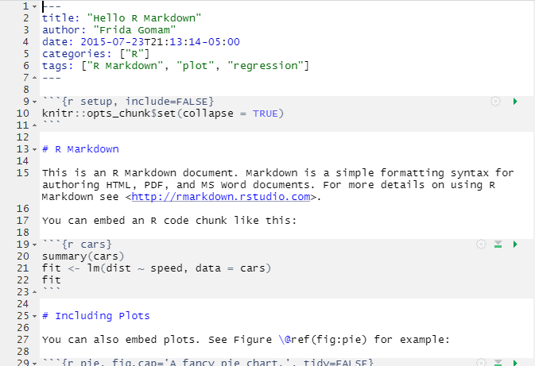

You can safely ignore that for now.

It will also often open up a version of your site in the viewer pane.

[figure not shown]

It may also open up a file titled config.toml. If it does, great! If not, go to the file that you’ve assigned as your working directory and open the config.toml file in a text-editing program like Notepad, Notepad++, or Atom. (Not to be confused with opening it up in a word processor like Word.)

[figure not shown]

Each site’s toml is going to be a little different. However, the things you’re going to be looking to change are things that are usually located near `[params]`. These include things like author, blog name, title, and description. These are the most important ones to look out for. Go ahead and change them to whatever you want. Here’s what it looks like after I edited a few of the parameters.

[figure not shown]

*Note: You don’t have to just stick with the same stuff as your theme if you don’t want to. There are bunch of different ways you could customize your site *via* the toml and the accompanying hmtl and javascript. I usually have luck looking for scss files, but it’ll take some pocking, prodding, and googling.*

### 5. Writing a New Post

Once you’ve made all the changes that you want, make sure that you’re in the same working directory as your site. Then go to the “addins” button near the top of your RStudio pane. Click “new post.” A RMarkdown document will open up. You can write in this as you would any other Rmarkdown document (and as you have been doing all of the assignments.)

Once you’re finished writing, be sure to save it. Then enter the command `blogdown::build_site()` into the console (or into your R script, so long as you run it.)

From here, open your GitHub desktop. Access the repository that you used to build your site (the one with the “Hello world!” html file, ending in “github.io”.) Either enter `ctrl+shift+f` or `cmd+shift+f` (depending on if you’re using either Windows or Mac), which will bring you to the GitHub file directory.

Using either file explorer or finder, go to the local directory where you have saved your blog. Open the folder called “public.” Copy *all* of the items inside the public folder. Delete the Hello World file from the GitHub desktop directory. Then paste all the contents of the public folder into your github.io repository. Push the changes to your GitHub account. Wait 5-10 minutes. Your site should now be live and ready for you to write new posts!

**You will have to do steps 5 and 6 every time you write a new post. However, most of the work is honestly finding and customizing the site. I hope this helps!**